# Replication Material Not Just Money: Unequal responsiveness in egalitarian democracies Journal of European Public Policy 2020

Lea Elsässer, Svenja Hense, Armin Schäfer

July 2020

In this file, we reproduce the analyses for the article Not just money: Unequal responsiveness in egalitarian democracies published with the Journal or European Public Policy. The article is based on an original dataset—“Responsiveness and Public Opinion in Germany” (ResPOG)—, which includes information on public opinion and respective political decisions for 746 policy proposals in Germany. We selected questions on reform proposals from two German representative surveys polled for different media: *Politbarometer* and *DeutschlandTrend*. The former covers the period from 1980 to 2013 and the latter from 1998 to 2013.

# Main part of the paper

In what follows, we reproduce all the figures that appear in the printed version of the paper. Additional graphs and tables can be found below in the Appendix, which is only available online.

## Figure 1

To give readers a sense of our data, *Figure 1* shows two scatter plots, each comparing the opinions of a ‘lower’ and an ‘upper’ group within one category of social stratification. As we can see, the degree of support for policy change correlates overall but, at the same time, there is considerable variation. The plots also show that only in a subset of cases the two respective groups have opposing interests, i.e. a majority in one group favors change whereas the majority in the other opposes it.

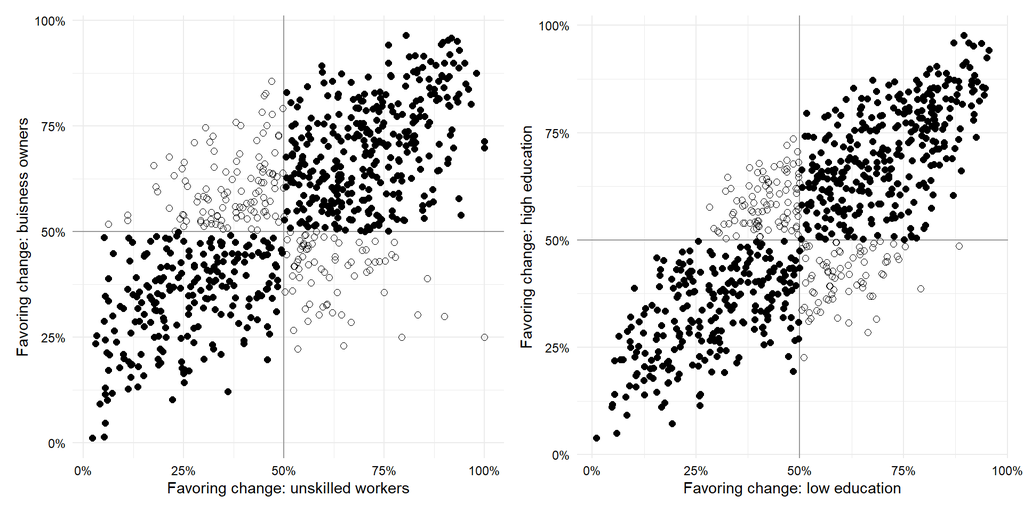

Figure 1: Correlation between policy preferences.

## Figure 2

*Figure 2* compares the distribution of opinion differences between educational and occupational groups across the two policy dimensions. Opinion differences on the economic policy dimension are larger between lower and upper occupational groups than between those with low and high formal education. When it comes to cultural issues, the distribution of opinion differences is similar across the two categories, although opinion differences are somewhat larger between educational groups.

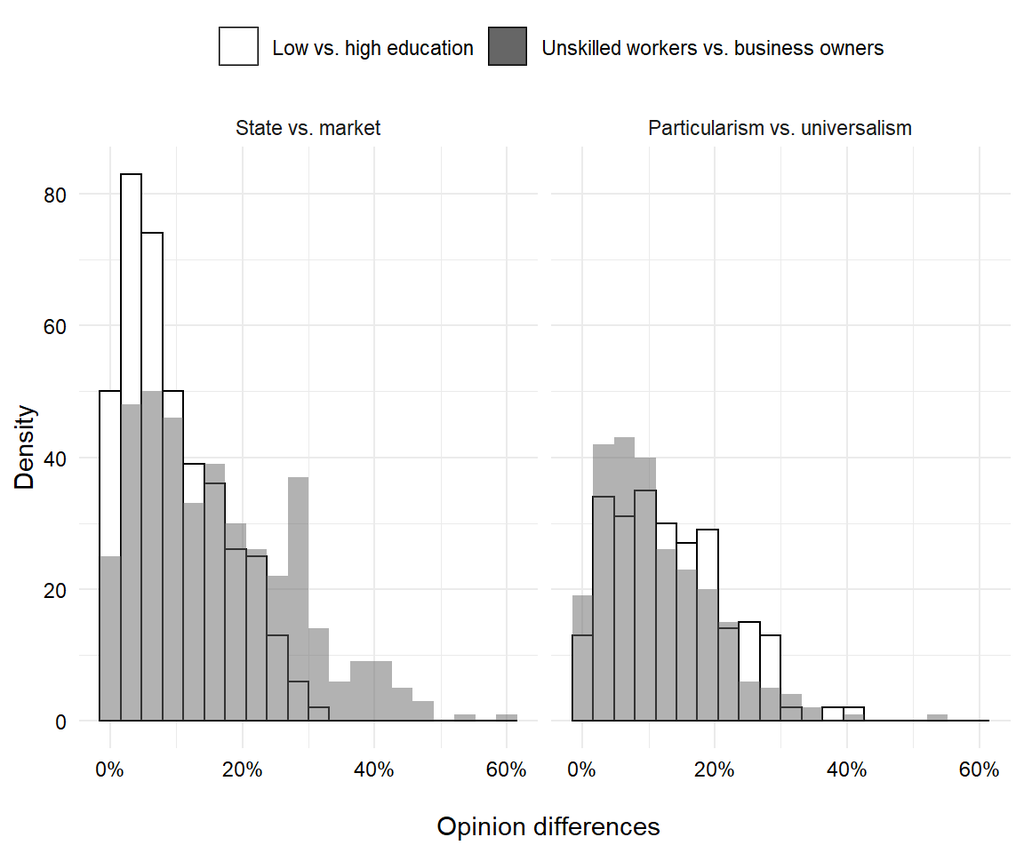

Figure 2: Opinion differences in two policy dimensions, by occupation and education

## Figure 3

The following analyses use the respective degree of support within different subgroups of respondents as the main explanatory variables. The dependent variable captures if the respective proposal was adopted within four years after the question was asked. *Figure 3* shows the coefficients of different logit models run independently of each other. Each model includes the share of support within one occupational or educational group. Full models are documented in Table A-4 and Table A-5 below. In addition, Table A-6 reports the results for income groups, which are based on fewer observations, though.

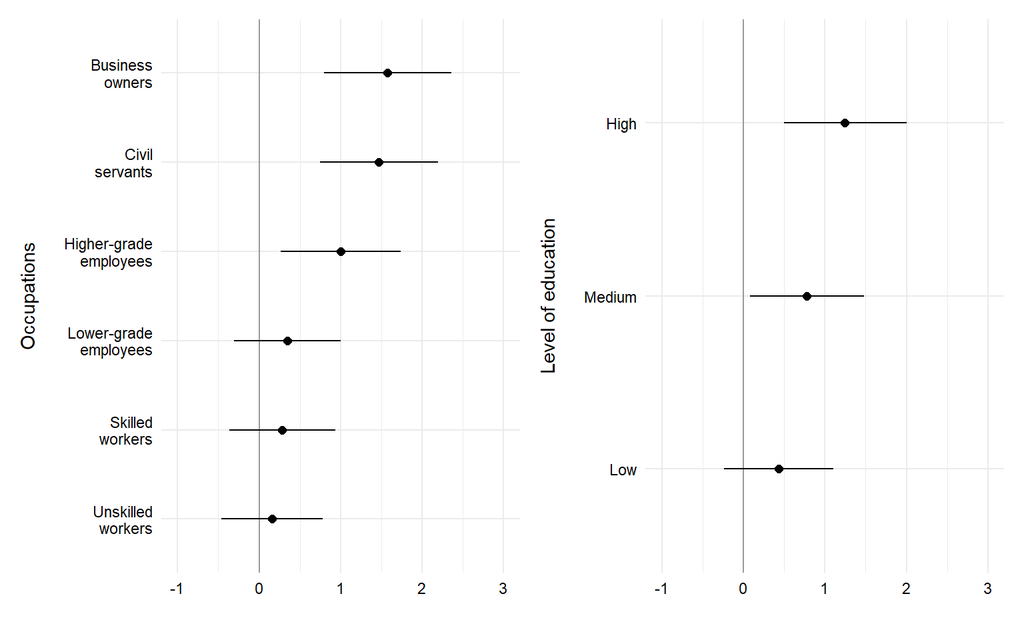

Figure 3: Regression coefficients that explain policy change

## Figure 4

To see how the size of opinion differences affects policy responsiveness, we interact the support for policy change of one group with the size of the opinion differences towards another group. Figure 4 shows the marginal effect of the preferences for policy change for four different groups conditioned on the size of opinion differences. Unskilled workers’ support for policy change only correlates positively with policy change if they agree with higher social classes. Once opinion differences increase beyond 10 percentage points, the effect becomes first insignificant and, with large differences, even negative. The more strongly workers disagree with business owners (and better-off groups in general), the more unlikely it becomes that the Bundestag implements their preferences. In contrast, the coefficient for business owners is always positive, even though it is imprecisely estimated with large opinion differences and fewer cases (upper right-hand panel in Figure 4). We find a similar pattern for education. The degree of support for policy change of those with lower levels of education has no significant impact on policy change—no matter how strongly their preferences coincide or diverge from those with higher levels of education.

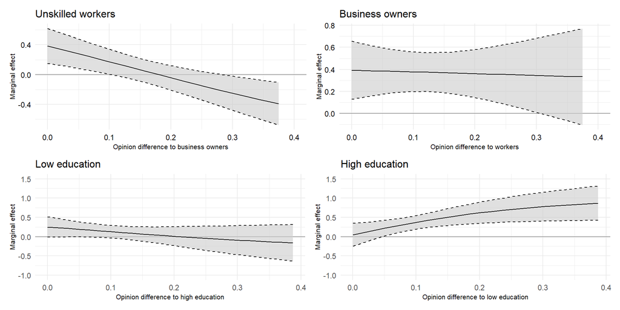

Figure 4: Marginal effect of preferences on policy change

## Figure 5

In a next step, we analyze whether the degree of responsiveness depends on a particular policy dimension or on the composition of parties in government. To this end, we first split our sample and run separate regressions for proposals assigned to the state-market dimension and for those assigned to the cultural dimension. As can be seen from Figure 5, we find a similar pattern of representational inequality in both policy dimensions.

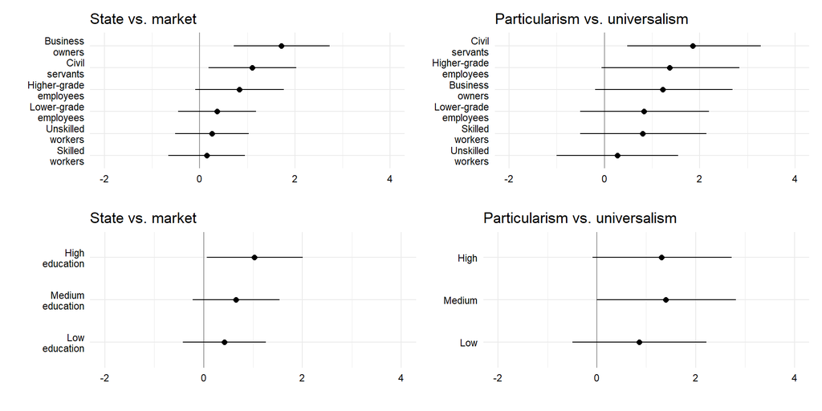

Figure 5: Responsiveness in two policy dimensions

# Appendix

In what follows, we document the plots and tables of the online appendix of the paper.

## Figure A-1

Figure A-1 shows the number of questions and the governing coalition at the time.

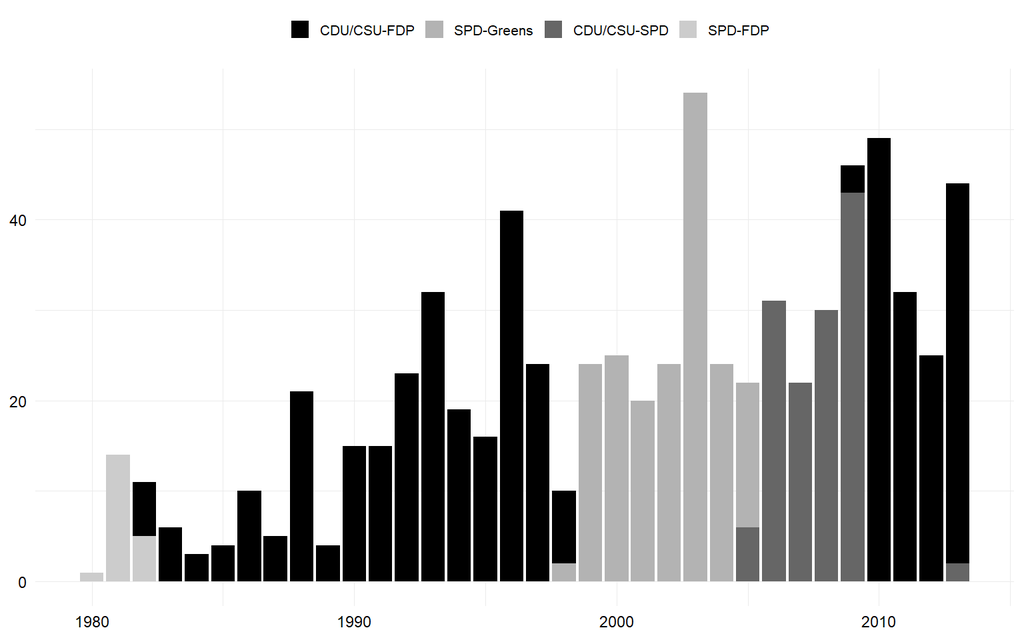

Figure 6: Number of questions per year and coalition government.

## Table A-1

Table A-1 in the Appendix of the paper displays the number of questions per policy field.

Table 1: Number of questions per policy field

| field | n | freq |
| --- | --- | --- |
| Foreign Policy | 73 | 0.10 |
| Economics & Finance | 199 | 0.27 |
| Labor market & Social policy | 216 | 0.29 |
| Environment | 40 | 0.05 |
| Migration | 44 | 0.06 |
| Society | 165 | 0.22 |
| Europe | 9 | 0.01 |

## Table A-2

Table A-2 in the Appendix of the paper documents the number of questions, in which two social groups hold opposing interest. The first table cross-tabulates unskilled workers and business owners, the second one repondents with low and high levels of education.

Table 2: Number of questions where unskilled workers and business owners hold opposing interests

| field | n | freq |
| --- | --- | --- |
| Foreign Policy | 24 | 0.13 |
| Economics & Finance | 44 | 0.24 |
| Labor market & Social policy | 60 | 0.32 |
| Environment | 8 | 0.04 |
| Migration | 7 | 0.04 |
| Society | 41 | 0.22 |
| Europe | 3 | 0.02 |

Table 2: Number of questions where respondents with low and high levels of education hold opposing interests

| field | n | freq |
| --- | --- | --- |
| Foreign Policy | 23 | 0.14 |
| Economics & Finance | 33 | 0.20 |
| Labor market & Social policy | 34 | 0.20 |
| Environment | 7 | 0.04 |
| Migration | 19 | 0.11 |
| Society | 53 | 0.31 |

## Figure A-2

Figure A-2 shows the absolute and relative number of questions that were implemented, subdivided by policy dimension.

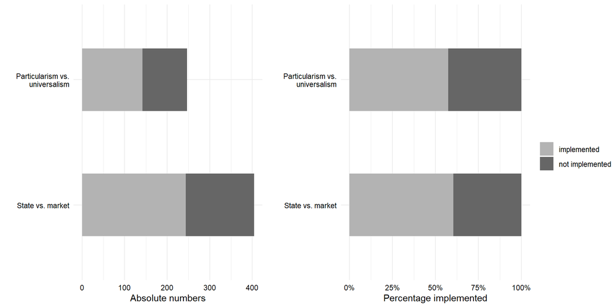

Figure 7: Absolute and relative number of questions by policy dimension.

## Figure A-3

Over time, many more citizens in Germany have acquired higher levels of education. *Figure A-3* compares the educational composition of occupational groups in the first and the last year of our analyses, 1980 and 2013. It mirrors the trend of an increase in average education in Europe over the last decades. However, clear differences remain: a majority of unskilled workers still comes from the group with lowest education, whereas higher-grade employees, business owners and civil servants comprised the highest share of highly-educated back then and now.

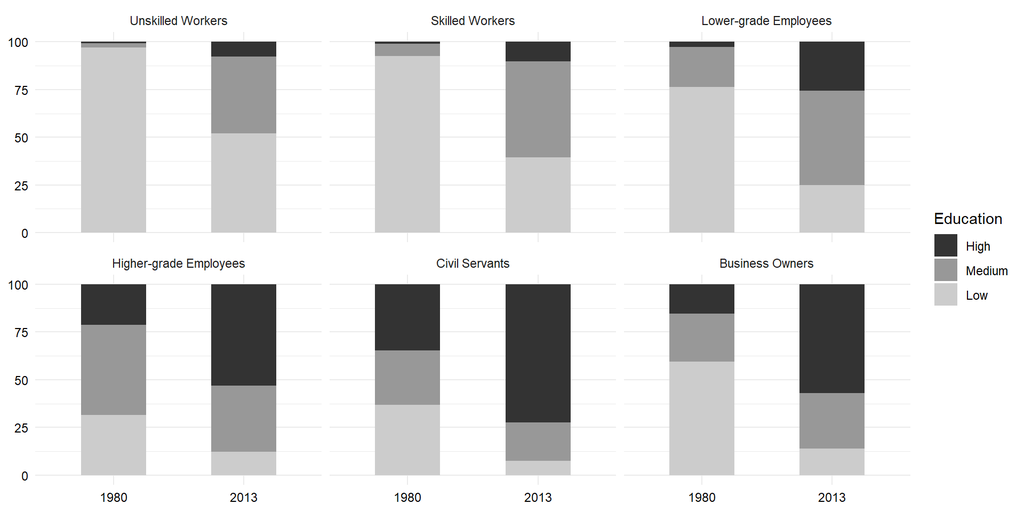

Figure 8: Share of educational levels by occupation, 1980 and 2013. Data: Politbarometer.

## Figure A-4

In our dataset, income is only available for a subset of questions. However, social class and income correlate strongly because the highest occupational groups are also those with the highest average income, as *Figure A-4* shows. Differences between occupational groups are pretty stable over time—even though lower groups experience a relative decline over time.

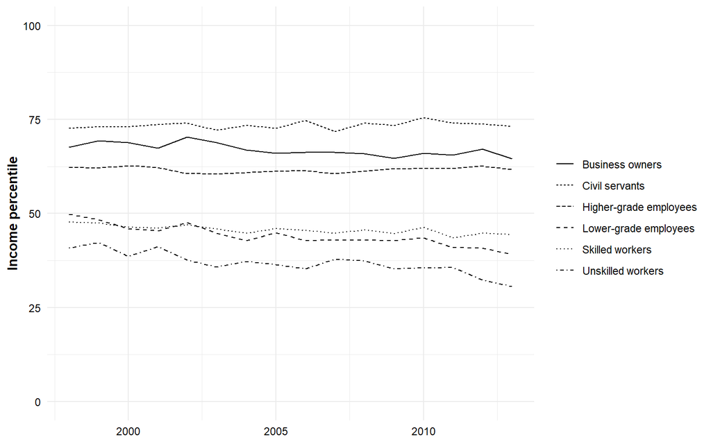

Figure 9: Income percentiles per group. Data: DeutschlandTrend, 1998-2013

## Table A-4

Regression models for **social class**:

Impact of preferences on policy change for social class

|  | Unskilled | Skilled | Lower-grade employees | Higher-grade employees | Civil servants | Business owners |
| --- | --- | --- | --- | --- | --- | --- |
| Logit coefficient | 0.160 | 0.283 | 0.345 | 1.000*** | 1.463*** | 1.571*** |
|  | (0.316) | (0.332) | (0.333) | (0.375) | (0.369) | (0.397) |
| Intercept | 0.331* | 0.266 | 0.232 | -0.119 | -0.383* | -0.437* |
|  | (0.179) | (0.188) | (0.190) | (0.212) | (0.212) | (0.226) |
| Num.Obs. | 746 | 746 | 746 | 746 | 746 | 746 |
| Log.Lik. | -501.365 | -501.130 | -500.959 | -497.897 | -493.434 | -493.457 |

* p < 0.1, ** p < 0.05, *** p < 0.01  
Cases consist of survey questions about proposed policy changes asked between 1980 and 2013. The dependent variable is policy outcome, coded 1 if the proposed policy took place within four years of the survey data and 0 if it did not. The predictors are the percentage of each group favoring policy change.

## Table A-5

Regression models for **education groups**:

Impact of preferences on policy change for education groups

|  | Low education | Medium education | High education |
| --- | --- | --- | --- |
| Logit coefficient | 0.434 | 0.777** | 1.246*** |
|  | (0.341) | (0.357) | (0.385) |
| Intercept | 0.187 | 0.004 | -0.248 |
|  | (0.192) | (0.201) | (0.216) |
| Num.Obs. | 746 | 746 | 746 |
| Log.Lik. | -500.682 | -499.105 | -496.173 |

* p < 0.1, ** p < 0.05, *** p < 0.01  
Cases consist of survey questions about proposed policy changes asked between 1980 and 2013. The dependent variable is policy outcome, coded 1 if the proposed policy took place within four years of the survey data and 0 if it did not. The predictors are the percentage of each group favoring policy change.

## Figure A-5

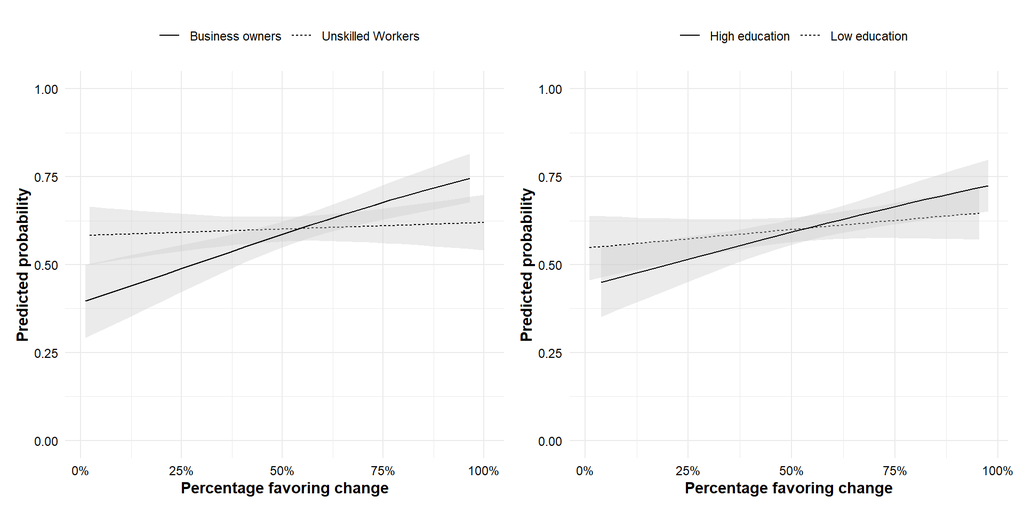

Figure 10: Predicted probability of policy change

## Table A-6

Regression models for **income groups**:

Impact of preferences on policy change for income groups

|  | 1st | 10th | 50th | 90th | 99th |
| --- | --- | --- | --- | --- | --- |
| Logit coefficient | -0.673 | -0.622 | 0.039 | 1.497* | 1.895** |
|  | (0.634) | (0.641) | (0.680) | (0.767) | (0.775) |
| Intercept | 0.880** | 0.853** | 0.494 | -0.314 | -0.537 |
|  | (0.372) | (0.377) | (0.396) | (0.443) | (0.448) |
| Num.Obs. | 222 | 222 | 222 | 222 | 222 |
| Log.Lik. | -146.171 | -146.264 | -146.737 | -144.799 | -143.665 |

* p < 0.1, ** p < 0.05, *** p < 0.01  
Cases consist of survey questions about proposed policy changes asked between 1980 and 2013. The dependent variable is policy outcome, coded 1 if the proposed policy took place within four years of the survey data and 0 if it did not. The predictors are the percentage of each group favoring policy change.

## Table A-7

Interaction of preferences for policy change and opinion differences.

Impact of preferences on policy change - depending on opinion differences

|  | Unskilled workers | Low education |
| --- | --- | --- |
| Coefficient | 1.619*** | 1.026* |
|  | (0.530) | (0.566) |
| Difference | 5.535*** | 5.177** |
|  | (1.627) | (2.530) |
| Interaction | -8.989*** | -4.882 |
|  | (2.730) | (4.411) |
| Intercept | -0.577* | -0.412 |
|  | (0.317) | (0.334) |
| Num.Obs. | 746 | 746 |
| Log.Lik. | -494.893 | -496.440 |

* p < 0.1, ** p < 0.05, *** p < 0.01  
This table shows the coefficients of a logistic regression model that interacts the support for policy change with opinion differences. For unskilled workers the opinion differences is measured against the preferences of business owners, for respondents with low levels of education it taps the opinion differences to those with high education.

## Table A-8

Responsiveness in two policy dimensions

|  | State vs market Unskilled1 | State vs market Skilled1 | State vs market Lower-grade employees1 | State vs market Higher-grade employees1 | State vs market Civil servants1 | State vs market Business owners1 |
| --- | --- | --- | --- | --- | --- | --- |
| Logit coefficient | 0.256 | 0.147 | 0.362 | 0.831* | 1.102** | 1.714*** |
|  | (0.394) | (0.411) | (0.417) | (0.474) | (0.469) | (0.512) |
| Intercept | 0.298 | 0.349 | 0.240 | -0.009 | -0.167 | -0.485* |
|  | (0.215) | (0.227) | (0.232) | (0.264) | (0.268) | (0.286) |
| Num.Obs. | 404 | 404 | 404 | 404 | 404 | 404 |
| Log.Lik. | -271.023 | -271.170 | -270.857 | -269.686 | -268.433 | -265.455 |

* p < 0.1, ** p < 0.05, *** p < 0.01

|  | Particularism vs universalism Unskilled | Particularism vs universalism Skilled | Particularism vs universalism Lower-grade employees | Particularism vs universalism Higher-grade employees | Particularism vs universalism Civil servants | Particularism vs universalism Business owners |
| --- | --- | --- | --- | --- | --- | --- |
| Logit coefficient | 0.272 | 0.807 | 0.833 | 1.368* | 1.854*** | 1.227* |
|  | (0.649) | (0.675) | (0.688) | (0.734) | (0.712) | (0.733) |
| Intercept | 0.144 | -0.159 | -0.177 | -0.464 | -0.732* | -0.390 |
|  | (0.397) | (0.406) | (0.415) | (0.429) | (0.415) | (0.431) |
| Num.Obs. | 247 | 247 | 247 | 247 | 247 | 247 |
| Log.Lik. | -168.338 | -167.708 | -167.687 | -166.658 | -164.917 | -167.002 |

* p < 0.1, ** p < 0.05, *** p < 0.01  
Cases consist of survey questions about proposed policy changes asked between 1980 and 2013. The dependent variable is policy outcome, coded 1 if the proposed policy took place within four years of the survey data and 0 if it did not. The predictors are the percentage of each group favoring policy change.

## Table A-9

Impact of preferences on policy change - two interactions

|  | Unskilled | Skilled | Lower-grade employee | Higher-grade employee | Civil servants | Business owners |
| --- | --- | --- | --- | --- | --- | --- |
| Class | 0.541 | 0.537 | 0.557 | 1.158* | 1.396** | 2.420*** |
|  | (0.586) | (0.610) | (0.623) | (0.685) | (0.667) | (0.788) |
| SPD-Greens | 0.597 | 0.793 | 0.540 | 0.556 | 0.039 | 0.698 |
|  | (0.504) | (0.536) | (0.547) | (0.641) | (0.654) | (0.694) |
| CDU/CSU-SPD | 0.933* | 0.908 | 0.692 | 0.772 | 0.762 | 1.220* |
|  | (0.547) | (0.564) | (0.586) | (0.636) | (0.642) | (0.678) |
| Policy dimension | -0.380 | -0.507 | -0.488 | -0.191 | 0.058 | 0.435 |
|  | (0.505) | (0.523) | (0.540) | (0.575) | (0.561) | (0.609) |
| Survey institute | -0.017 | -0.021 | -0.024 | -0.030 | -0.019 | -0.035 |
|  | (0.196) | (0.196) | (0.196) | (0.195) | (0.196) | (0.197) |
| Class * CDU/CSU-SPD | -0.405 | -0.348 | 0.015 | -0.100 | -0.053 | -0.797 |
|  | (0.902) | (0.949) | (0.977) | (1.096) | (1.092) | (1.184) |
| Class * SPD-Greens | -0.884 | -1.272 | -0.758 | -0.750 | 0.174 | -0.925 |
|  | (0.922) | (0.955) | (0.967) | (1.100) | (1.086) | (1.176) |
| Class * dimension | 0.267 | 0.524 | 0.442 | -0.088 | -0.541 | -1.196 |
|  | (0.845) | (0.880) | (0.901) | (0.970) | (0.932) | (1.022) |
| Intercept | -0.219 | -0.224 | -0.216 | -0.539 | -0.689 | -1.266** |
|  | (0.389) | (0.404) | (0.410) | (0.442) | (0.440) | (0.498) |
| Num.Obs. | 563 | 563 | 563 | 563 | 563 | 563 |
| Log.Lik. | -380.686 | -380.103 | -380.284 | -378.958 | -377.057 | -374.501 |

## Figure A-6

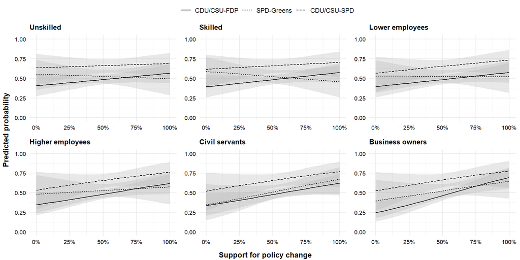